# Predict the maner by using Human Activity Recognition

Van Mai

Sunday, May 17, 2015

#### The Goal

The goal of this project is to predict the manner in which the people did the exercise. This is the “classe” variable in the training set.

#### The Data

More information is available from the website http://groupware.les.inf.puc-rio.br/har

The training data for this project are available here: https://d396qusza40orc.cloudfront.net/predmachlearn/pml-training.csv

The test data are available here: https://d396qusza40orc.cloudfront.net/predmachlearn/pml-testing.csv

The data for this project come from this source: http://groupware.les.inf.puc-rio.br/har.

#### The Exericise

##### Load the data

```r
## Read the training and testing data
trainingSrc <- read.csv("pml-training.csv", na.strings = c("", "NA", "NULL"))
testingSrc <- read.csv("pml-testing.csv", na.strings = c("", "NA", "NULL"))
dim(trainingSrc);
```

```
## [1] 19622   160
```

```r
dim(testingSrc);
```

```
## [1]  20 160
```

##### Tiding the data

I think we should use the variables that not have NA value to model. I will use **colSums(is.na(the_variable))** to count the number of NA value in variable.

```r
trainingSrc <- trainingSrc[, colSums(is.na(trainingSrc)) == 0]
dim(trainingSrc)
```

```
## [1] 19622    60
```

Not use the un-relate variable “X”, “user_name”, “raw_timestamp_part_1”, “raw_timestamp_part_2”, “cvtd_timestamp”, “new_window”, “num_window”

```r
colNamesRemove <- c('X', 'user_name', 'raw_timestamp_part_1', 'raw_timestamp_part_2', 'cvtd_timestamp', 'new_window', 'num_window')
trainingSrc <- trainingSrc[, - which(names(trainingSrc) %in% colNamesRemove)]
dim(trainingSrc)
```

```
## [1] 19622    53
```

##### Plit trainingSrc to training and testing for cross validation

```r
## 60% training - 40% testing
library(caret)
set.seed(112357)
inTrain <- createDataPartition(trainingSrc$classe, p = 0.6, list = FALSE)
training <- trainingSrc[inTrain, ]
testing <- trainingSrc[-inTrain, ]

## use training to model
#data <- training[, 1:20]
#class <- training$classe
```

##### Use method “rpart”

```r
modFitRPart <- train(classe ~ ., method = "rpart", data = training)
#modFit <- rpart(classe ~ ., data = training)
print(modFitRPart$finalModel)
```

```
## n= 11776
##
## node), split, n, loss, yval, (yprob)
##       * denotes terminal node
##
##  1) root 11776 8428 A (0.28 0.19 0.17 0.16 0.18)
##    2) roll_belt< 130.5 10766 7427 A (0.31 0.21 0.19 0.18 0.11)
##      4) pitch_forearm< -33.95 967    6 A (0.99 0.0062 0 0 0) *
##      5) pitch_forearm>=-33.95 9799 7421 A (0.24 0.23 0.21 0.2 0.12)
##       10) magnet_dumbbell_y< 438.5 8281 5949 A (0.28 0.18 0.24 0.19 0.11)
##         20) roll_forearm< 124.5 5174 3080 A (0.4 0.18 0.18 0.17 0.058) *
##         21) roll_forearm>=124.5 3107 2072 C (0.077 0.17 0.33 0.23 0.19) *
##       11) magnet_dumbbell_y>=438.5 1518  725 B (0.03 0.52 0.045 0.22 0.18) *
##    3) roll_belt>=130.5 1010    9 E (0.0089 0 0 0 0.99) *
```

Prettier plots

```r
library(rattle)
```

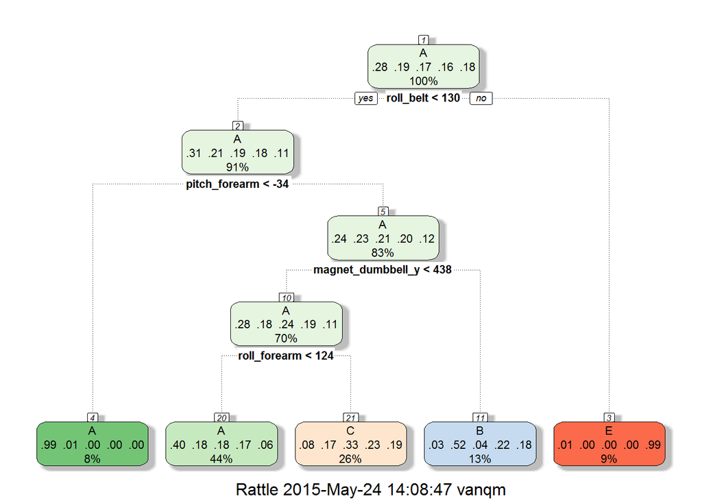

```r
fancyRpartPlot(modFitRPart$finalModel)
```

Use **modFitRPart** to predict the **testing** data and look the accuracy

```r
preRPart <- predict(modFitRPart, newdata = testing)
## The accuracy of method "rpart"
confMatrix <- confusionMatrix(preRPart, testing$classe)
confMatrix$overall[1]
```

```
##  Accuracy
## 0.4895488
```

The accuracy of **rpart** method is 0.4895488. It is too small to get the dicision.

##### Use method “Random Forest”

```r
require(randomForest)
modFitRF <- randomForest(classe ~ ., data = training)
print(modFitRF)
```

```
##
## Call:
##  randomForest(formula = classe ~ ., data = training)
##                Type of random forest: classification
##                      Number of trees: 500
## No. of variables tried at each split: 7
##
##         OOB estimate of  error rate: 0.65%
## Confusion matrix:
##      A    B    C    D    E class.error
## A 3344    2    0    0    2 0.001194743
## B   15 2258    6    0    0 0.009214568
## C    1   14 2034    5    0 0.009737098
## D    0    0   22 1907    1 0.011917098
## E    0    0    1    7 2157 0.003695150
```

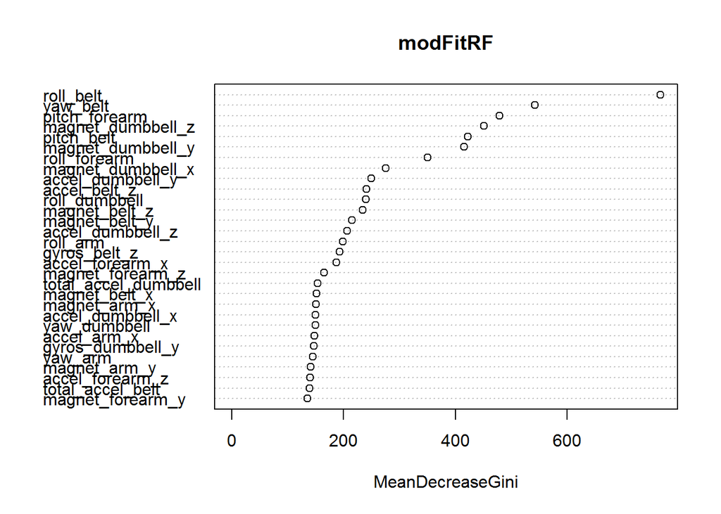

```r
# plot the importance of variables
varImpPlot(modFitRF)
```

Use **modFitRF** to predict the **testing** and see the accuracy

```r
preRF <- predict(modFitRF, newdata = testing)
## The accuracy of method "rf"
confMatrix <- confusionMatrix(preRF, testing$classe)
confMatrix$overall[1]
```

```
##  Accuracy
## 0.9917155
```

#### Conclusion

Use **modFitRF** to predict the result of *testingSrc*

```r
dim(testingSrc)
```

```
## [1]  20 160
```

```r
predTestingSrc <- predict(modFitRF, newdata = testingSrc)
print(predTestingSrc);
```

```
##  1  2  3  4  5  6  7  8  9 10 11 12 13 14 15 16 17 18 19 20
##  B  A  B  A  A  E  D  B  A  A  B  C  B  A  E  E  A  B  B  B
## Levels: A B C D E
```

```r
## use predTestingSrc to generate the answers for submision project
pml_write_files = function(x){
    n = length(x)
    for(i in 1:n){
        filename = paste0("problem_id_", i, ".txt")
        write.table(x[i], file=filename, quote=FALSE, row.names=FALSE, col.names=FALSE)
    }
}
pml_write_files(predTestingSrc)
```